# Weather

Varun Vasudeva

10/19/2020

# Weather Classification Neural Network

This model was built to preempt, based on a simple table of given weather conditions, whether the day would be rainy or snowy. It demonstrates the efficiency of deep learning on large datasets with many recordings. The benefit of a model like this is that this classification required no data that a sensor-equipped small weather station can’t provide.

Data: https://www.kaggle.com/budincsevity/szeged-weather

```r
library(tensorflow)
library(keras)
library(reticulate)
library(tidyverse)
library(caret)
use_condaenv("r-reticulate")
use_backend("plaidml")
```

```r
weather <- read.csv("weatherHistory.csv")
head(weather)
```

```
##                  Formatted.Date       Summary Precip.Type Temperature..C.
## 1 2006-04-01 00:00:00.000 +0200 Partly Cloudy        rain        9.472222
## 2 2006-04-01 01:00:00.000 +0200 Partly Cloudy        rain        9.355556
## 3 2006-04-01 02:00:00.000 +0200 Mostly Cloudy        rain        9.377778
## 4 2006-04-01 03:00:00.000 +0200 Partly Cloudy        rain        8.288889
## 5 2006-04-01 04:00:00.000 +0200 Mostly Cloudy        rain        8.755556
## 6 2006-04-01 05:00:00.000 +0200 Partly Cloudy        rain        9.222222
##   Apparent.Temperature..C. Humidity Wind.Speed..km.h. Wind.Bearing..degrees.
## 1                 7.388889     0.89           14.1197                    251
## 2                 7.227778     0.86           14.2646                    259
## 3                 9.377778     0.89            3.9284                    204
## 4                 5.944444     0.83           14.1036                    269
## 5                 6.977778     0.83           11.0446                    259
## 6                 7.111111     0.85           13.9587                    258
##   Visibility..km. Loud.Cover Pressure..millibars.
## 1         15.8263          0              1015.13
## 2         15.8263          0              1015.63
## 3         14.9569          0              1015.94
## 4         15.8263          0              1016.41
## 5         15.8263          0              1016.51
## 6         14.9569          0              1016.66
##                       Daily.Summary
## 1 Partly cloudy throughout the day.
## 2 Partly cloudy throughout the day.
## 3 Partly cloudy throughout the day.
## 4 Partly cloudy throughout the day.
## 5 Partly cloudy throughout the day.
## 6 Partly cloudy throughout the day.
```

Below, we remove unnecessary data such as `Summary`, `Daily.Summary`, and `Loud.Cover`. Since we are only concerned with creating a model that can accurately classify whether the day will feature rain or snow, and not with creating any visual time-series plots, the `Formatted.Date` data is also unnecessary.

```r
weather <- weather %>%
  select(!(Formatted.Date|Summary|Daily.Summary|Loud.Cover)) %>%
  rename(precip = Precip.Type, temp = Temperature..C., atemp = Apparent.Temperature..C., humidity = Humidity, windspeed = Wind.Speed..km.h., windbearing = Wind.Bearing..degrees., visibility = Visibility..km., pressure = Pressure..millibars.) %>%
  filter(precip == "rain" | precip == "snow") %>%
  mutate(precip = as.factor(precip)) %>%
  drop_na()

head(weather)
```

```
##   precip     temp    atemp humidity windspeed windbearing visibility pressure
## 1   rain 9.472222 7.388889     0.89   14.1197         251    15.8263  1015.13
## 2   rain 9.355556 7.227778     0.86   14.2646         259    15.8263  1015.63
## 3   rain 9.377778 9.377778     0.89    3.9284         204    14.9569  1015.94
## 4   rain 8.288889 5.944444     0.83   14.1036         269    15.8263  1016.41
## 5   rain 8.755556 6.977778     0.83   11.0446         259    15.8263  1016.51
## 6   rain 9.222222 7.111111     0.85   13.9587         258    14.9569  1016.66
```

Then, we create a split the data into train, validation, and test subsets. The training set constitutes 60% of the entire data, the validation 20%, and the test also 20%. We one-hot encode the labels for all three sets in order to be able to feed it into the model.

```r
train_prop <- 0.60
val_prop <- 0.20
test_prop <- 0.20

train_size <- floor(train_prop * nrow(weather))
val_size <- floor(val_prop * nrow(weather))
test_size <- floor(test_prop * nrow(weather))

train_indices <- sort(sample(seq_len(nrow(weather)), size = train_size))
temp <- setdiff(seq_len(nrow(weather)), train_indices)
val_indices <- sort(sample(temp, size = val_size))
test_indices <- setdiff(temp, val_indices)

train <- weather[train_indices, ]
validation <- weather[val_indices, ]
test <- weather[test_indices, ]

train_data <- select(train, !precip)
train_labels <- select(train, precip)
val_data <- select(validation, !precip)
val_labels <- select(validation, precip)
test_data <- select(test, !precip)
test_labels <- select(test, precip)

train_data <- data.matrix(train_data)
train_labels <- data.matrix(train_labels)
val_data <- data.matrix(val_data)
val_labels <- data.matrix(val_labels)
test_data <- data.matrix(test_data)
test_labels <- data.matrix(test_labels)

train_labels <- to_categorical(train_labels)
val_labels <- to_categorical(val_labels)
test_labels <- to_categorical(test_labels)
```

We include a small sanity check here to ensure that our data is in the correct number of dimensions and of the same order before using it as an input for the neural network.

```r
dim(train_data)
```

```
## [1] 57561     7
```

```r
dim(train_labels)
```

```
## [1] 57561     3
```

```r
dim(val_data)
```

```
## [1] 19187     7
```

```r
dim(val_labels)
```

```
## [1] 19187     3
```

```r
dim(test_data)
```

```
## [1] 19188     7
```

```r
dim(test_labels)
```

```
## [1] 19188     3
```

```r
head(train_data)
```

```
##        temp     atemp humidity windspeed windbearing visibility pressure
## 1  9.472222  7.388889     0.89   14.1197         251    15.8263  1015.13
## 2  9.355556  7.227778     0.86   14.2646         259    15.8263  1015.63
## 4  8.288889  5.944444     0.83   14.1036         269    15.8263  1016.41
## 6  9.222222  7.111111     0.85   13.9587         258    14.9569  1016.66
## 7  7.733333  5.522222     0.95   12.3648         259     9.9820  1016.72
## 9 10.822222 10.822222     0.82   11.3183         259     9.9820  1017.37
```

```r
head(train_labels)
```

```
##      [,1] [,2] [,3]
## [1,]    0    1    0
## [2,]    0    1    0
## [3,]    0    1    0
## [4,]    0    1    0
## [5,]    0    1    0
## [6,]    0    1    0
```

The model itself is a multi-layer perceptron with 227,219 trainable parameters. It has 5 dense layers: the first four utilize the ReLu and Sigmoid activation functions and the fifth layer consists of only 3 units and utilizes a Softmax activation in order to classify rain or snow.

```r
network <- keras_model_sequential() %>%
  layer_dense(units = 512, activation = 'relu', input_shape = c(7)) %>%
  layer_dense(units = 256, activation = 'relu') %>%
  layer_dense(units = 256, activation = 'sigmoid') %>%
  layer_dense(units = 100, activation = 'relu') %>%
  layer_dense(units = 3, activation = 'softmax')

network %>% compile(
  optimizer = 'rmsprop',
  loss = 'categorical_crossentropy',
  metrics = c('accuracy')
)

network
```

```
## Model
## ________________________________________________________________________________
## Layer (type)                        Output Shape                    Param #
## ================================================================================
## dense_1 (Dense)                     (None, 512)                     4096
## ________________________________________________________________________________
## dense_2 (Dense)                     (None, 256)                     131328
## ________________________________________________________________________________
## dense_3 (Dense)                     (None, 256)                     65792
## ________________________________________________________________________________
## dense_4 (Dense)                     (None, 100)                     25700
## ________________________________________________________________________________
## dense_5 (Dense)                     (None, 3)                       303
## ================================================================================
## Total params: 227,219
## Trainable params: 227,219
## Non-trainable params: 0
## ________________________________________________________________________________
```

```r
history <- network %>%
  fit(train_data, train_labels, epochs = 10, verbose = 2, validation_data = list(val_data, val_labels))
metrics <- network %>%
  evaluate(test_data, test_labels)
```

We can see that the model achieves a weather prediction accuracy of over 99% using basic measurements of air and weather characteristics. While it is certainly not the level of weather updates we expect now, the use of neural networks will be interesting to see in fields that are yet to adopt deep learning techniques.

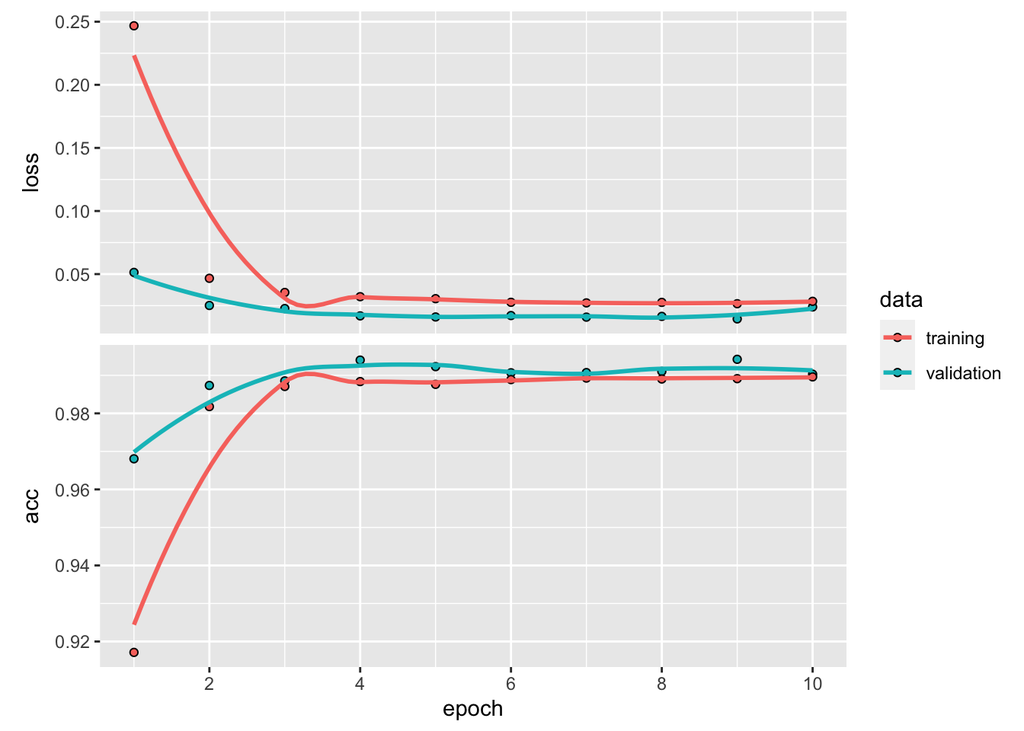

```r
plot(history)
```

```r
metrics
```

```
## $loss
## [1] 0.02468743
##
## $acc
## [1] 0.990567
```